# MA_Hw_05_02

## Packages

```r
suppressMessages(library(plyr))
suppressMessages(library(rethinking))
suppressMessages(library(rstan))
suppressMessages(library(tidyverse))
suppressMessages(library(ggplot2))
suppressMessages(library(skimr)) # for n_unique func
```

## Data-processing

### Read data

```r
data("Hurricanes")
Hurricanes
```

| name | year | deaths | category | min_pressure | damage_norm | female | femininity |
| --- | --- | --- | --- | --- | --- | --- | --- |
| Easy | 1950 | 2 | 3 | 960 | 1590 | 1 | 6.77778 |
| King | 1950 | 4 | 3 | 955 | 5350 | 0 | 1.38889 |
| Able | 1952 | 3 | 1 | 985 | 150 | 0 | 3.83333 |
| Barbara | 1953 | 1 | 1 | 987 | 58 | 1 | 9.83333 |
| Florence | 1953 | 0 | 1 | 985 | 15 | 1 | 8.33333 |
| Carol | 1954 | 60 | 3 | 960 | 19321 | 1 | 8.11111 |
| Edna | 1954 | 20 | 3 | 954 | 3230 | 1 | 8.55556 |
| Hazel | 1954 | 20 | 4 | 938 | 24260 | 1 | 9.44444 |
| Connie | 1955 | 0 | 3 | 962 | 2030 | 1 | 8.50000 |
| Diane | 1955 | 200 | 1 | 987 | 14730 | 1 | 9.88889 |

[output cut: 82 more lines]

## PART A

### Model

#### Poisson Model

For the parameters,  
I set beta_f to be the coefficient of femininity.  
And the difference between two models are that one doesn’t considers the femininity of name, yet another does.

```r
q2_model_with_f = "
data {
    int N;
    int death[N];
  real femininity[N];
}
parameters {
    real alpha;
    real beta_f;
}
transformed parameters {
    real lambda[N];
    for (i in 1:N){
        lambda[i] = exp(alpha + beta_f*femininity[i]);
    }
}
model {
    // model
    death ~ poisson(lambda);

    // prior
    alpha ~ normal(0, 10);
    beta_f ~ normal(0, 5);
}
generated quantities {
    real log_lik[N];
    real pred_lambda[N];
    real pred_death[N];

    for (i in 1:N){
        log_lik[i] = poisson_lpmf(death[i] | lambda[i]);
    }
    for (i in 1:N){
        pred_lambda[i] = exp(alpha + beta_f*femininity[i]);
    }
    for (i in 1:N){
        pred_death[i] = poisson_rng(pred_lambda[i]);
    }
}
"
q2_model_no_f = "
data {
    int N;
  int death[N];
}
parameters {
    real alpha;
}
transformed parameters {
    real lambda[N];
    for (i in 1:N){
        lambda[i] = exp(alpha);
    }
}
model {
    // model
    death ~ poisson(lambda);

    // prior
    alpha ~ normal(0, 10);
}
generated quantities {
    real log_lik[N];

    for (i in 1:N){
        log_lik[i] = poisson_lpmf(death[i] | lambda[i]);
    }
}
"
```

```r
q2_data_with_f = list(
          N = nrow(Hurricanes),
          femininity = Hurricanes$femininity,
          death = Hurricanes$deaths
)
q2_data_no_f = list(
          N = nrow(Hurricanes),
          death = Hurricanes$deaths
)
```

#### Fit

```r
q2_fit_with_f = stan(
                  model_code = q2_model_with_f,
                  data = q2_data_with_f,
                  cores = 2, chains = 2,
                  warmup = 1500, iter = 3000)
```

```
starting worker pid=27610 on localhost:11275 at 21:48:56.688
starting worker pid=27624 on localhost:11275 at 21:48:56.975
```

```r
q2_fit_no_f = stan(
                  model_code = q2_model_no_f,
                  data = q2_data_no_f,
                  cores = 2, chains = 2,
                  warmup = 1500, iter = 3000)
```

```
starting worker pid=27640 on localhost:11275 at 21:49:03.008
starting worker pid=27654 on localhost:11275 at 21:49:03.287
```

### Check the posteriors

we can see that all the R hat of paras of both models are 1, which means they are convergent

```r
options(max.print=1000000)
print(q2_fit_with_f, pars = c("alpha", "beta_f"))
```

```
Inference for Stan model: 5520c06f19bafcb89bd2631b551f2a99.
2 chains, each with iter=3000; warmup=1500; thin=1;
post-warmup draws per chain=1500, total post-warmup draws=3000.

       mean se_mean   sd 2.5%  25%  50%  75% 97.5% n_eff Rhat
alpha  2.50       0 0.06 2.37 2.45 2.50 2.54  2.62   649    1
beta_f 0.07       0 0.01 0.06 0.07 0.07 0.08  0.09   658    1

Samples were drawn using NUTS(diag_e) at Sun Jun  7 21:48:59 2020.
For each parameter, n_eff is a crude measure of effective sample size,
and Rhat is the potential scale reduction factor on split chains (at
convergence, Rhat=1).
```

```r
print(q2_fit_no_f, pars = c("alpha"))
```

```
Inference for Stan model: a4e7dbbcb790cd2156de8806a45dc868.
2 chains, each with iter=3000; warmup=1500; thin=1;
post-warmup draws per chain=1500, total post-warmup draws=3000.

      mean se_mean   sd 2.5%  25%  50%  75% 97.5% n_eff Rhat
alpha 3.03       0 0.02 2.98 3.01 3.03 3.04  3.08  1024    1

Samples were drawn using NUTS(diag_e) at Sun Jun  7 21:49:06 2020.
For each parameter, n_eff is a crude measure of effective sample size,
and Rhat is the potential scale reduction factor on split chains (at
convergence, Rhat=1).
```

### Compare Two model

we can see that the model with fimininity seems to be a little better.

```r
compare(q2_fit_with_f, q2_fit_no_f)
```

|  | WAIC | SE | dWAIC | dSE | pWAIC | weight |
| --- | --- | --- | --- | --- | --- | --- |
| q2_fit_with_f | 4409.6 | 999.32 | 0.0 | NA | 133.4 | 1 |
| q2_fit_no_f | 4454.8 | 1078.08 | 45.2 | 141.96 | 84.3 | 0 |

### Association

We can see, via the picture, the association between femininity of name and deaths isn’t strong, though the deadlies hurricanes seems to be a bit more feminine in name.

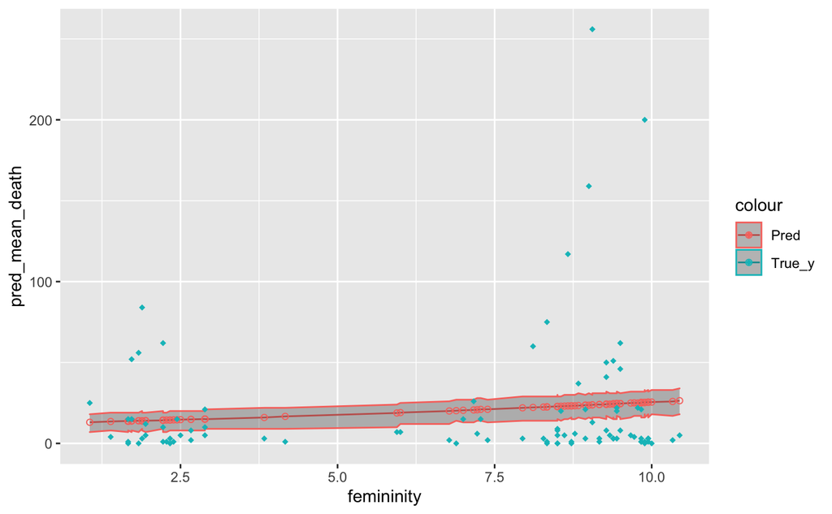

```r
q2_post_with_f = as.data.frame(q2_fit_with_f, pars = "pred_death")

q2_result_with_f = Hurricanes %>%
  mutate(
    pred_mean_death = q2_post_with_f %>% apply(., 2, mean),
    PI_lower = q2_post_with_f %>% apply(., 2, HPDI) %>% .[1,],
    PI_upper = q2_post_with_f %>% apply(., 2, HPDI) %>% .[2,])

q2_pic_with_f = q2_result_with_f %>%
  ggplot() +
  geom_line(aes(femininity, pred_mean_death, color ="Pred")) +
  geom_ribbon(aes(x = femininity, ymin=PI_lower, ymax=PI_upper, color ="Pred"), alpha = .3)+
  geom_point(data = q2_result_with_f, aes(femininity, pred_mean_death, color ="Pred"), shape=21) +
  geom_point(data = q2_result_with_f, aes(femininity, deaths, color ="True_y"), shape=18)

q2_pic_with_f
```

### Fit performance

And We also can know, via the above picture and the folloing dataframe,  
The Model fits the Strom which is closer to the mean of pred_death best : Dennis,  
and it fits the Strom which is far higher than our CI worst : Camille.

```r
q2_result_with_f$dis_y_pred = abs(q2_result_with_f$pred_mean_death - q2_result_with_f$deaths)

best = q2_result_with_f$name[q2_result_with_f$dis_y_pred == min(q2_result_with_f$dis_y_pred)]
worst = q2_result_with_f$name[q2_result_with_f$dis_y_pred == max(q2_result_with_f$dis_y_pred)]
print(paste0("The model fit best on ", best))
```

```
[1] "The model fit best on Dennis"
```

```r
print(paste0("The model fit Worst on ", worst))
```

```
[1] "The model fit Worst on Camille"
```

## PART B

### Model

#### Gamma Poisson Model

For the parameters,  
I set beta_f to be the coefficient of femininity, and set phi for getting higher degree of freedom.

```r
q2_model_B = "
data {
    int N;
    int death[N];
  real femininity[N];
}
parameters {
    real alpha;
    real beta_f;
  real phi;
}
transformed parameters {
    real lambda[N];
    for (i in 1:N){
        lambda[i] = exp(alpha + beta_f*femininity[i]);
    }
}
model {
    // model
    death ~ neg_binomial_2(lambda, phi);

    // prior
    alpha ~ normal(0, 10);
    beta_f ~ normal(0, 5);
    phi ~ cauchy(0, 2);

}
generated quantities {
    real log_lik[N];
    real pred_lambda[N];
    real pred_death[N];

    for (i in 1:N){
        log_lik[i] = neg_binomial_2_lpmf(death[i] | lambda[i], phi);
        pred_lambda[i] = exp(alpha + beta_f*femininity[i]);
        pred_death[i] = neg_binomial_2_rng(pred_lambda[i], phi);
    }
}

"
```

```r
q2_data_B = list(
          N = nrow(Hurricanes),
          femininity = Hurricanes$femininity,
          death = Hurricanes$deaths
)
```

#### Fit

```r
q2_fit_B = stan(
                  model_code = q2_model_B,
                  data = q2_data_B,
                  cores = 2, chains = 2,
                  warmup = 1500, iter = 3000)
```

```
starting worker pid=27670 on localhost:11275 at 21:49:10.884
starting worker pid=27684 on localhost:11275 at 21:49:11.170
```

### Check the posteriors

we can see that all the R hat of paras are 1, which means they are convergent

```r
options(max.print=1000000)
print(q2_fit_B, pars = c("alpha", "beta_f", "phi"))
```

```
Inference for Stan model: 8e59a270c12e21b5582be574d7f2bcf2.
2 chains, each with iter=3000; warmup=1500; thin=1;
post-warmup draws per chain=1500, total post-warmup draws=3000.

       mean se_mean   sd  2.5%  25%  50%  75% 97.5% n_eff Rhat
alpha  2.56    0.01 0.36  1.93 2.30 2.55 2.79  3.27  1035    1
beta_f 0.07    0.00 0.05 -0.03 0.04 0.07 0.10  0.16  1058    1
phi    0.46    0.00 0.06  0.34 0.41 0.45 0.49  0.59  1201    1

Samples were drawn using NUTS(diag_e) at Sun Jun  7 21:49:14 2020.
For each parameter, n_eff is a crude measure of effective sample size,
and Rhat is the potential scale reduction factor on split chains (at
convergence, Rhat=1).
```

### Association

The reason the association between femininity and deaths diminished in strength may be:  
The original model may omit some varible that accounts for the variance.  
After we revise the poisson distribution model to the gamma poisson distribution model, the model would have more degree of freedom, and therefore be more similar to it real distribution, and then we can see the real association.

To sum up, there may be no(or only very very weak) association, but because of the limitation of the poisson distribution, we are misled to believe there is association. By using gamma poisson distribution, we get the better result.

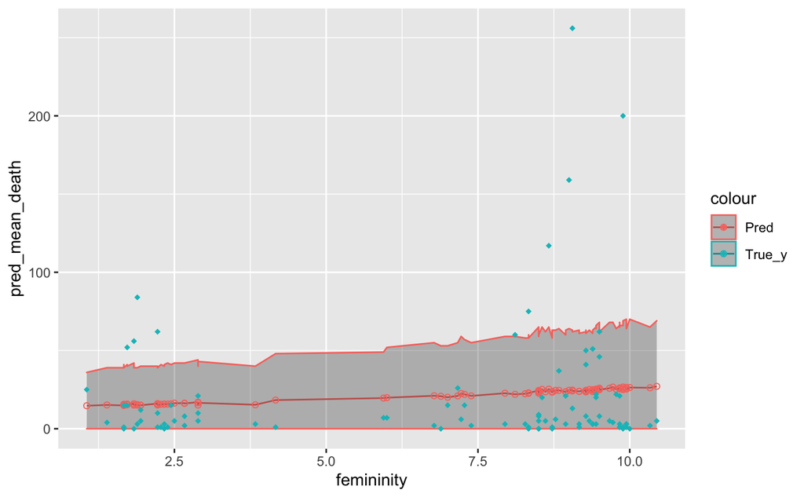

```r
q2_post_B = as.data.frame(q2_fit_B, pars = "pred_death")

q2_result_B = Hurricanes %>%
  mutate(
    pred_mean_death = q2_post_B %>% apply(., 2, mean),
    PI_lower = q2_post_B %>% apply(., 2, HPDI) %>% .[1,],
    PI_upper = q2_post_B %>% apply(., 2, HPDI) %>% .[2,])

q2_pic_B = q2_result_B %>%
  ggplot() +
  geom_line(aes(femininity, pred_mean_death, color ="Pred")) +
  geom_ribbon(aes(x = femininity, ymin=PI_lower, ymax=PI_upper, color ="Pred"), alpha = .3)+
  geom_point(data = q2_result_B, aes(femininity, pred_mean_death, color ="Pred"), shape=21) +
  geom_point(data = q2_result_B, aes(femininity, deaths, color ="True_y"), shape=18)

q2_pic_B
```